# Workshop 5 Fiancial Econometrics

Juan David Torres

Mar 10 2021

Download the stock data from GRUMA

```r
library(quantmod)
getSymbols(c("GRUMAB.MX", "^MXX"), from="2017-01-01", to="2020-03-11", periodicity="daily", src="yahoo")
```

[output not shown]

```
## [1] "GRUMAB.MX" "^MXX"
```

Show 5 first values of GRUMA

```r
head(GRUMAB.MX,5)
```

```
##            GRUMAB.MX.Open GRUMAB.MX.High GRUMAB.MX.Low GRUMAB.MX.Close
## 2017-01-02         263.50         264.00        262.01          263.10
## 2017-01-03         263.97         265.00        257.50          258.77
## 2017-01-04         260.06         266.06        257.00          265.74
## 2017-01-05         265.74         275.00        264.46          274.41
## 2017-01-06         266.00         275.00        266.00          274.64
##            GRUMAB.MX.Volume GRUMAB.MX.Adjusted
## 2017-01-02            22518           240.7950
## 2017-01-03           420265           236.8321
## 2017-01-04          1120534           243.2112
## 2017-01-05          1175996           251.6196
## 2017-01-06           860582           251.8306
```

Show 5 first values of MXX

```r
head(MXX,5)
```

```
##            MXX.Open MXX.High  MXX.Low MXX.Close MXX.Volume MXX.Adjusted
## 2017-01-02 45642.80 45792.46 45593.26  45695.10    6765800     45695.10
## 2017-01-03 45698.93 46444.72 45690.46  46123.36  164938800     46123.36
## 2017-01-04 46123.36 46587.74 46068.83  46587.74  215385900     46587.74
## 2017-01-05 46586.03 46767.37 46285.88  46719.99  237288300     46719.99
## 2017-01-06 46721.70 46731.90 46027.10  46071.57  201371200     46071.57
```

Visualize the daily stocks prices for GRUMA

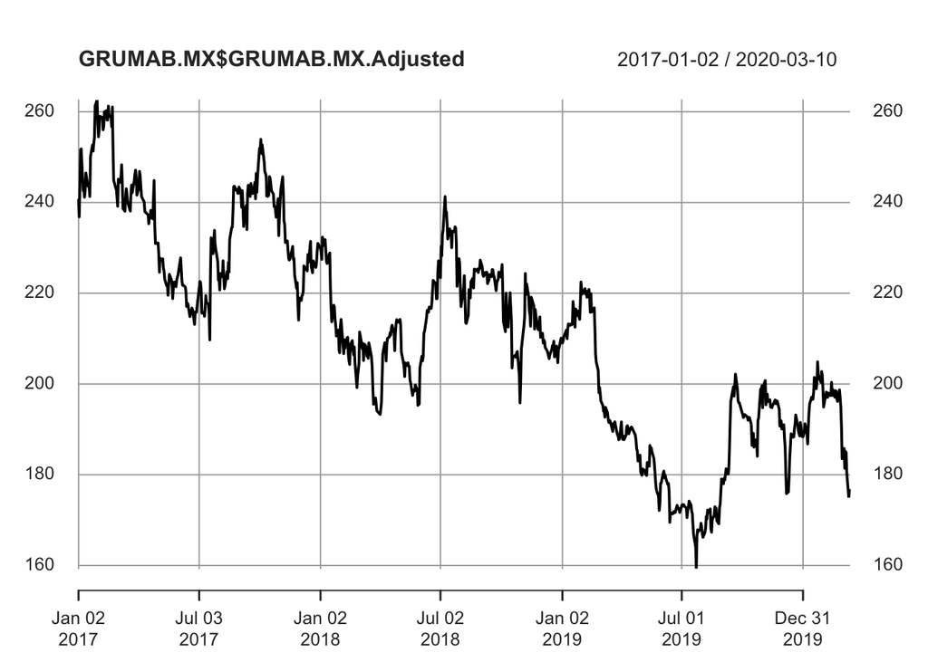

```r
plot(GRUMAB.MX$GRUMAB.MX.Adjusted)
```

Visualize the daily stocks prices for MXX

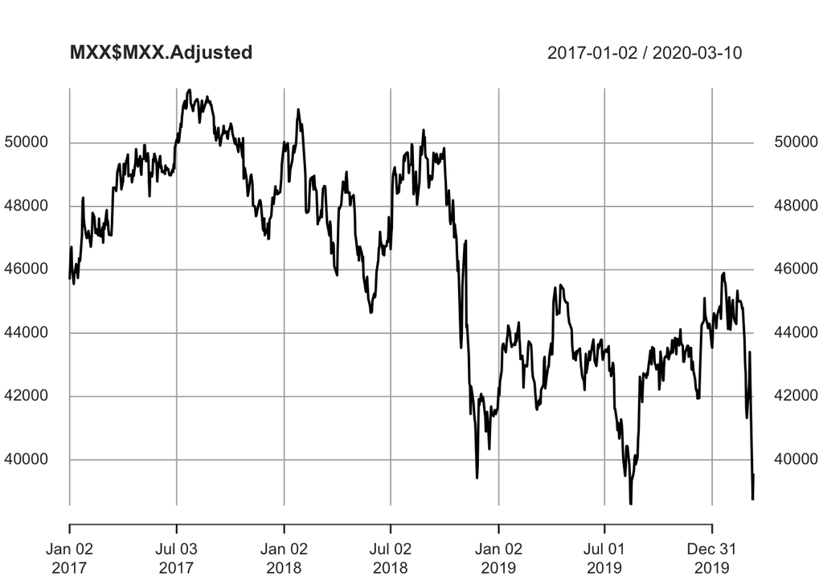

```r
plot(MXX$MXX.Adjusted)
```

Calculate CC Returns from GRUMA and plot them

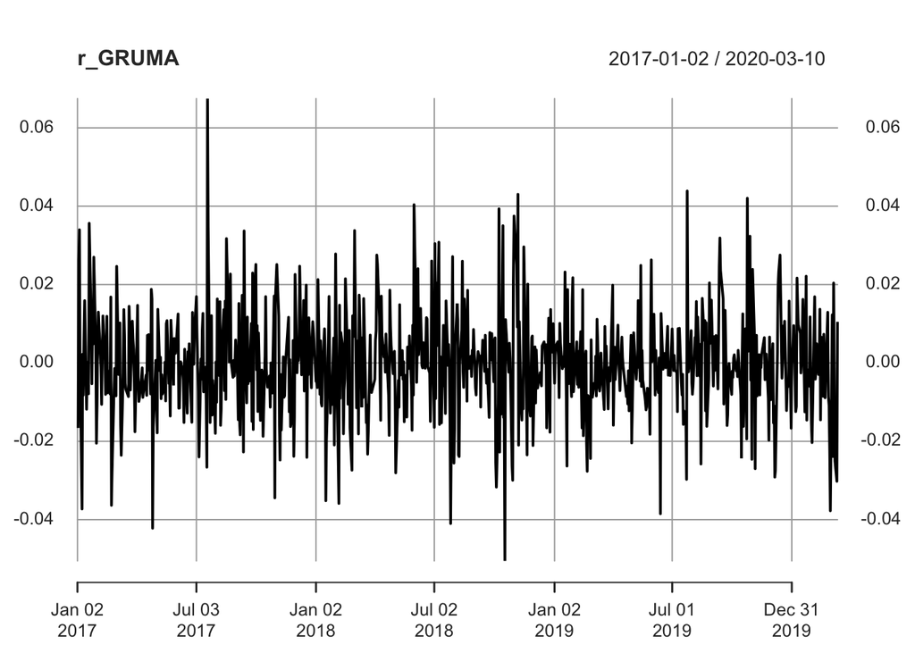

```r
r_GRUMA <- diff(log(Ad(GRUMAB.MX)))
plot(r_GRUMA)
```

Calculate CC Returns of MXX and plot them

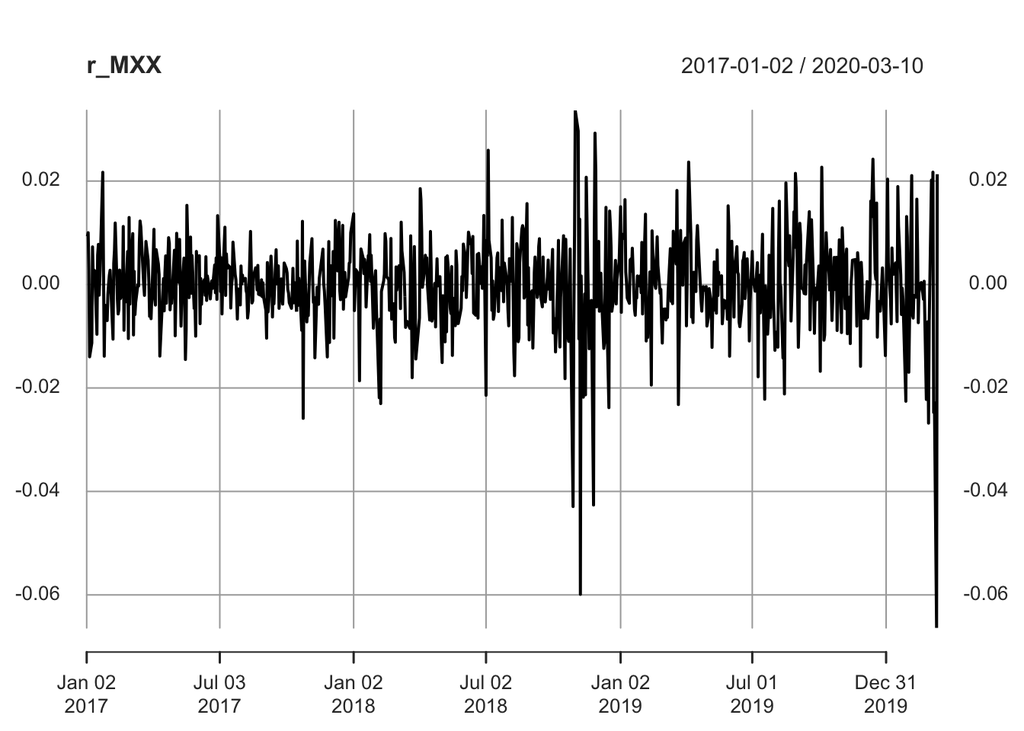

```r
r_MXX <- diff(log(Ad(MXX)))
plot(r_MXX)
```

Visualize the linear relationship between Gruma and MXX

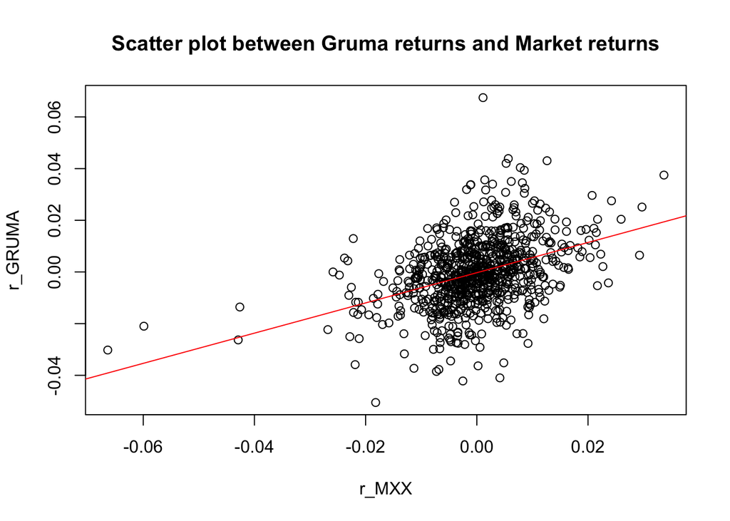

```r
plot(as.numeric(r_MXX), as.numeric(r_GRUMA), type = "p", xlab = "r_MXX", ylab = "r_GRUMA", main = "Scatter plot between Gruma returns and Market returns")
abline(lm(r_GRUMA~r_MXX), col="red")
```

Market Regression Model for GRUMA in specific dates

```r
# Change the dates and assign them to a temporal value
r_GRUMA_bef <- r_GRUMA["2017-01-02/2020-03-06"]


ie <- r_GRUMA[1:799,]

# Do the same for the returns of the market
r_MXX_bef <- r_MXX["2017-01-02/2020-03-06"]

# The lm() is used to create a linear regression
bef_bm <- lm(r_GRUMA_bef ~ as.vector(r_MXX_bef))


class(bef_bm)
```

```
## [1] "lm"
```

Visualize content of the linear regression model

```r
names(bef_bm)
```

```
##  [1] "coefficients"  "residuals"     "effects"       "rank"
##  [5] "fitted.values" "assign"        "qr"            "df.residual"
##  [9] "na.action"     "xlevels"       "call"          "terms"
## [13] "model"
```

Access the names and visualize the coefficients

```r
summ_bef_bm <- summary(bef_bm)

summ_bef_bm$coefficients
```

```
##                           Estimate   Std. Error    t value     Pr(>|t|)
## (Intercept)          -0.0002884309 0.0004395498 -0.6561962 5.118876e-01
## as.vector(r_MXX_bef)  0.5949982876 0.0500974110 11.8768271 4.567387e-30
```

What is the regression equation of this model? WRITE it as comments in your R script.

r_GRUMA = 0.5949982876 * r_MXX -0.0002884309

Show 5 last values of MXX

```r
tail(r_MXX, 5)
```

```
##            MXX.Adjusted
## 2020-03-04   0.02171823
## 2020-03-05  -0.02472212
## 2020-03-06  -0.02283717
## 2020-03-09  -0.06638094
## 2020-03-10   0.02132713
```

Show 5 last values of GRUMA

```r
tail(r_GRUMA, 5)
```

```
##            GRUMAB.MX.Adjusted
## 2020-03-04        0.020391944
## 2020-03-05       -0.001206561
## 2020-03-06       -0.025035198
## 2020-03-09       -0.030216820
## 2020-03-10        0.010485285
```

Predict with the value of the MXX value of monday

```r
predict(bef_bm, newdata = data.frame(r_MXX_bef = -0.06638094))
```

```
##           1
## -0.03978498
```